# Mission n°3

Voici quelques questions supplémentaires, que votre manager vous a posées :

1. Y a-t-il une corrélation entre le sexe des clients et les catégories de produits achetés ?
2. Y a-t-il une corrélation entre l'âge des clients et :  
   2.1 le montant total des achats  
   2.2 la fréquence d’achat (ie. nombre d'achats par mois par exemple)  
   2.3 la taille du panier moyen (en nombre d’articles)  
   2.4 les catégories de produits achetés

### Table des matières

#### 1. Corrélation entre genre et catégories de produits achetés

- Tableau de contingences 'sex' et 'categ'
- Heatmap

#### 2. Corrélation entre l'âge des clients et le montant total des achats

- Préparation du dataframe
- Méthode des moindres carrés (OLS)
- Création du graphique
- Découpage du dataframe en 3 groupes d'âge

#### 3. Corrélation entre l'âge des clients et le nombre d’achats

- Préparation du dataframe
- Méthode des moindres carrés (OLS)
- Création du graphique
- Découpage du dataframe en 3 groupes d'âge

#### 4. Corrélation entre l'âge des clients et la taille du panier moyen (en nombre d’articles)

- Préparation du dataframe
- Méthode des moindres carrés (OLS)
- Création du graphique
- Découpage du dataframe en 3 groupes d'âge

#### 5. Corrélation entre l'âge des clients et les catégories de produits achetés

- Préparation du dataframe et affichage du boxplot
- Calculs préparatoires
- ANOVA
- F distribution (Fisher-Snedecor)
- Vérification des hypothèses

```python
# Import des librairies
import numpy as np
import pandas as pd

import matplotlib.pyplot as plt
from matplotlib import patches
%matplotlib inline

from pylab import rcParams
import seaborn as sns

import scipy as sc
import scipy.stats as st
import statsmodels.api as sm
```

```python
# rappel de la table clean
table_clean = pd.read_csv('data/table_clean.csv')
table_clean.head(1)
```

|  | level_0 | index | session_id | client_id | sex | age | id_prod | price | categ | timeline | date | year | month | day | hour | timestamp |
| --- | --- | --- | --- | --- | --- | --- | --- | --- | --- | --- | --- | --- | --- | --- | --- | --- |
| 0 | 0 | 0 | s_12716 | c_6624 | m | 69.0 | 1_264 | 16.07 | 1 | 2021-03 | 28-03-2021 | 2021 | 3 | Sunday | 17 | 2021-03-28 17:16:26.325707 |

## 1. [tdm] corrélation entre genre et catégories de produits achetés

- 'sex' et 'categ' sont **2 variables qualitatives**
- Nous utiliserons donc le [test du Khi-2](https://fr.khanacademy.org/math/statistics-probability/inference-categorical-data-chi-square-tests/chi-square-tests-for-homogeneity-and-association-independence/v/contingency-table-chi-square-test)

**Hypothèse nulle (H0)** : la catégorie de produits achetés est indépendante du sexe des clients  
**Hypothèse alternative (H1)** : la catégorie de produits achetés est dépendante du sexe des clients  
**Seuil de tolérance α** : 5% pour l'hypothèse nulle (seuil généralement admis en sciences sociales)

#### 1. [tdm] Tableau de contingences 'sex' et 'categ'

```python
cont = table_clean[['sex', 'categ', 'client_id']].copy()

# pivot de 'categ'
cont = cont.pivot_table(index=['sex'], columns=['categ'], values=['client_id'], aggfunc='count').reset_index()
cont.columns = ['sex', '0_obs', '1_obs', '2_obs']

cont
```

|  | sex | 0_obs | 1_obs | 2_obs |
| --- | --- | --- | --- | --- |
| 0 | f | 101206 | 53774 | 8122 |
| 1 | m | 94064 | 48851 | 7634 |

```python
# ajout des totaux
cont['tot_obs'] = cont['0_obs'] + cont['1_obs'] + cont['2_obs']
tot_obs = cont['0_obs'].sum() + cont['1_obs'].sum() + cont['2_obs'].sum()
total = ['total', cont['0_obs'].sum(), cont['1_obs'].sum(), cont['2_obs'].sum(), tot_obs]
cont.loc[len(cont)] = total
cont
```

|  | sex | 0_obs | 1_obs | 2_obs | tot_obs |
| --- | --- | --- | --- | --- | --- |
| 0 | f | 101206 | 53774 | 8122 | 163102 |
| 1 | m | 94064 | 48851 | 7634 | 150549 |
| 2 | total | 195270 | 102625 | 15756 | 313651 |

```python
# calcul des résultats "attendus"
att=cont.copy()
#Calcul des ratios
rf = att.loc[0]['tot_obs'] / att.loc[2]['tot_obs']
rm = att.loc[1]['tot_obs'] / att.loc[2]['tot_obs']
#rt = att.loc[2]['tot_obs']

att['ratio'] = [rf,rm,1]

att['0_att'] = att.loc[2]['0_obs'] * att['ratio']
att['1_att'] = att.loc[2]['1_obs'] * att['ratio']
att['2_att'] = att.loc[2]['2_obs'] * att['ratio']

arr = pd.Series([3, 0, 0, 0], index=['ratio', '0_att', '1_att', '2_att'])
att = att.round(arr)
```

- Carrés des ecarts entre les valeurs observées et les valeurs attendues, divisés par les valeurs attendues

```python
att['khi2_0'] = (att['0_obs'] - att['0_att'])**2 / att['0_att']
att['khi2_1'] = (att['1_obs'] - att['1_att'])**2 / att['1_att']
att['khi2_2'] = (att['2_obs'] - att['2_att'])**2 / att['2_att']
att
```

|  | sex | 0_obs | 1_obs | 2_obs | tot_obs | ratio | 0_att | 1_att | 2_att | khi2_0 | khi2_1 | khi2_2 |
| --- | --- | --- | --- | --- | --- | --- | --- | --- | --- | --- | --- | --- |
| 0 | f | 101206 | 53774 | 8122 | 163102 | 0.52 | 101543.0 | 53366.0 | 8193.0 | 1.118433 | 3.119289 | 0.615281 |
| 1 | m | 94064 | 48851 | 7634 | 150549 | 0.48 | 93727.0 | 49259.0 | 7563.0 | 1.211700 | 3.379362 | 0.666534 |
| 2 | total | 195270 | 102625 | 15756 | 313651 | 1.00 | 195270.0 | 102625.0 | 15756.0 | 0.000000 | 0.000000 | 0.000000 |

```python
# khi2 = somme des carrés précédents
khi2 = att['khi2_0'].sum() + att['khi2_1'].sum() + att['khi2_2'].sum()
round(khi2,3)
```

```
10.111
```

- Calcul du **degré de liberté** = (nb de lignes - 1) * (nb de colonnes - 1) **DDL = 2**
- Recherche de la valeur de seuil et de la position du Chi2 calculé dans la [Table de la loi du khi-deux](https://archimede.mat.ulaval.ca/stt1920/STT-1920-Loi-du-khi-deux.pdf)
  - **α =0.05**
  - **Valeur de seuil = 5.99**
- Le **khi2 de 10.111** et supérieur à la **valeur de seuil de 5.99**
- La **pvalue** (la probabilité) que l'hypothèse H0 se réalise est inférieure à 1%
- On donc peut rejeter l'hypothèse H0

[figure not shown]

[**Vérification avec un calculateur en ligne**](https://www.socscistatistics.com/pvalues/chidistribution.aspx)

[figure not shown]

#### 2. [tdm] Heatmap

```python
# heatmap pour genre vs toutes catégories
heat = att[['khi2_0','khi2_1','khi2_2']].copy()
heat = heat.drop(heat.index[2])
heat.rename(columns={'khi2_0':'cat0','khi2_1':'cat1','khi2_2':'cat2',},
            index={0:'Femmes',1:'Hommes'},inplace=True)
heat = round(heat,2)
heat
```

|  | cat0 | cat1 | cat2 |
| --- | --- | --- | --- |
| Femmes | 1.12 | 3.12 | 0.62 |
| Hommes | 1.21 | 3.38 | 0.67 |

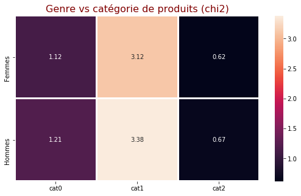

```python
# heatmap
plt.figure(figsize=(9,5))
plt.title('Genre vs catégorie de produits (chi2)', fontsize=16, color='maroon')

display_heat = sns.heatmap(heat, linewidths =2, annot=True, fmt='.2f')


plt.savefig('img/Q3/1.2 heatmap.png', dpi=120, bbox_inches='tight')
plt.show()
plt.close()
```

- On peut constater avec cette hitmap que, si nous sommes dans l'hypothèse H1, la différence entre sexe n'est pas spectaculaire
- La différence la plus marquée est dans la catégorie 1 oú l'écart est de 0.26
- **Pour affiner le résultat**, nous pourrions créer des catégories par sexe et par âge en utilisant les 3 populations précédemment identifiées :
  - **<=30 | 31-50 | >50** - soit 3 autres tableaux de 6 cellules

## 2. [tdm] Corrélation entre l'âge des clients et le montant total des achats

- 'age' et 'montant des achats' sont des variable quantitatives basées sur la **somme** de 'price'
- l'âge entrant en ligne de compte, nous excluerons l'outlier **18 ans**
- Pour ce type de variables nous utilisons le coefficient de corrélation linéaire de type **y =ax + b + epsilon**
- Nous utiliserons une régression linéaire et la méthode OLS (Ordinary Least Square) ou **méthode de moindre carrés**

#### 1. [tdm] Préparation du dataframe

```python
age =table_clean[['age','price']].copy()
# exclusion de l'outlier '18 ans'
age = age[(age['age'] != 18)]
# groupby et sum de 'price'
age = age.groupby(['age']).price.sum().reset_index()
age.describe()
```

|  | age | price |
| --- | --- | --- |
| count | 75.000000 | 75.000000 |
| mean | 56.000000 | 67576.986533 |
| std | 21.794495 | 48995.570416 |
| min | 19.000000 | 1300.030000 |
| 25% | 37.500000 | 18447.725000 |
| 50% | 56.000000 | 68926.580000 |
| 75% | 74.500000 | 109187.925000 |
| max | 93.000000 | 163722.820000 |

#### 2. [tdm] Méthode des moindres carrés (OLS)

```python
# déclaration de la variable dépendante et de la variable indépendante
x1 = age['age']
y = age['price']
# régression
x = sm.add_constant(x1)
results = sm.OLS(y,x).fit()
results.summary()
```

OLS Regression Results

| Dep. Variable: | price | R-squared: | 0.723 |
| --- | --- | --- | --- |
| Model: | OLS | Adj. R-squared: | 0.719 |
| Method: | Least Squares | F-statistic: | 190.4 |
| Date: | Tue, 26 Feb 2019 | Prob (F-statistic): | 4.95e-22 |
| Time: | 22:52:10 | Log-Likelihood: | -867.75 |
| No. Observations: | 75 | AIC: | 1740. |
| Df Residuals: | 73 | BIC: | 1744. |
| Df Model: | 1 |  |  |
| Covariance Type: | nonrobust |  |  |

|  | coef | std err | t | P>\|t\| | [0.025 | 0.975] |
| --- | --- | --- | --- | --- | --- | --- |
| const | 1.746e+05 | 8316.050 | 20.997 | 0.000 | 1.58e+05 | 1.91e+05 |
| age | -1911.3593 | 138.511 | -13.799 | 0.000 | -2187.412 | -1635.307 |

| Omnibus: | 6.314 | Durbin-Watson: | 0.437 |
| --- | --- | --- | --- |
| Prob(Omnibus): | 0.043 | Jarque-Bera (JB): | 5.532 |
| Skew: | 0.596 | Prob(JB): | 0.0629 |
| Kurtosis: | 3.589 | Cond. No. | 167. |

Warnings:  
[1] Standard Errors assume that the covariance matrix of the errors is correctly specified.

#### 3. [tdm] Création du graphique

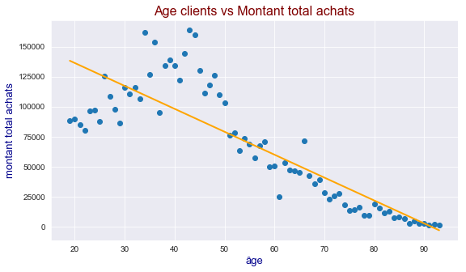

```python
sns.set_style("darkgrid")
plt.figure(figsize=(9,5))
plt.title('Age clients vs Montant total achats', fontsize=16, color='maroon')
plt.xlabel('âge', color='darkblue', size=13)
plt.ylabel('montant total achats', color='darkblue', size=13)

# La droite de régression linéaire est du type y = ax + b + epsilon
plt.scatter(x1,y)
# on prend les coef pour const et age pour le calcul du yhat
yhat = x1*-1911.3593+1.746e+05
fig = plt.plot(x1,yhat, lw=2, c='orange', label ='regression line')



plt.savefig('img/Q3/2.3 age_vs_tot_achats.png', dpi=120, bbox_inches='tight')
plt.show()
plt.close()
```

```python
# coefficient de corrélation de Pearson
age = st.pearsonr(age["age"],age["price"])[0]
round(age, 3)
```

```
-0.85
```

**Conclusion**

- On pourrait dire qu'il y a une corrélation linéaire négative assez élevée pour cet ensemble de données, mais le graphique le dément partiellement
- Par soucis de cohérence avec les observations précédentes et futures nous allons séparer en 3 groupes d'âge
  - de 19 à 30 ans, corrélation positive moyenne
  - de 31 à 50 ans, pas de corrélation
  - à partir de 51 ans une forte corrélation négative

#### 4. [tdm] Découpage du dataframe en 3 groupes d'âge

- Nous étutions la corrélation pour les 19-30 ans, les 31-50 ans et les 51-93 ans

##### 4.1 Analyse des 19-30 ans

```python
# âge a : les moins de 30 ans
agea=table_clean[['age','price']].copy()
# limitation à 30 ans inclus
agea = agea.loc[(agea['age'] != 18) & (agea['age'] <= 30),:]
# groupby et sum de 'price'
agea = agea.groupby(['age']).price.sum().reset_index()
agea.describe()
```

|  | age | price |
| --- | --- | --- |
| count | 12.000000 | 12.000000 |
| mean | 24.500000 | 96579.600833 |
| std | 3.605551 | 13698.197473 |
| min | 19.000000 | 80109.910000 |
| 25% | 21.750000 | 87502.625000 |
| 50% | 24.500000 | 93217.565000 |
| 75% | 27.250000 | 100229.947500 |
| max | 30.000000 | 125475.990000 |

```python
# déclaration de la variable dépendante et de la variable indépendante
x1 = agea['age']
y = agea['price']
# régression
x = sm.add_constant(x1)
results = sm.OLS(y,x).fit()
results.summary()
```

OLS Regression Results

| Dep. Variable: | price | R-squared: | 0.283 |
| --- | --- | --- | --- |
| Model: | OLS | Adj. R-squared: | 0.212 |
| Method: | Least Squares | F-statistic: | 3.952 |
| Date: | Tue, 26 Feb 2019 | Prob (F-statistic): | 0.0749 |
| Time: | 22:52:10 | Log-Likelihood: | -128.81 |
| No. Observations: | 12 | AIC: | 261.6 |
| Df Residuals: | 10 | BIC: | 262.6 |
| Df Model: | 1 |  |  |
| Covariance Type: | nonrobust |  |  |

|  | coef | std err | t | P>\|t\| | [0.025 | 0.975] |
| --- | --- | --- | --- | --- | --- | --- |
| const | 4.704e+04 | 2.52e+04 | 1.869 | 0.091 | -9031.782 | 1.03e+05 |
| age | 2021.9817 | 1017.127 | 1.988 | 0.075 | -244.320 | 4288.283 |

| Omnibus: | 2.326 | Durbin-Watson: | 2.153 |
| --- | --- | --- | --- |
| Prob(Omnibus): | 0.313 | Jarque-Bera (JB): | 0.589 |
| Skew: | 0.495 | Prob(JB): | 0.745 |
| Kurtosis: | 3.443 | Cond. No. | 178. |

Warnings:  
[1] Standard Errors assume that the covariance matrix of the errors is correctly specified.

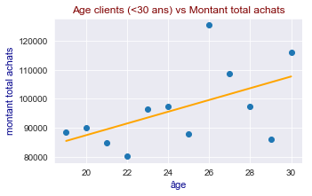

```python
sns.set_style("darkgrid")
plt.figure(figsize=(5,3))
plt.title('Age clients (<30 ans) vs Montant total achats', fontsize=12, color='maroon')
plt.xlabel('âge', color='darkblue', size=11)
plt.ylabel('montant total achats', color='darkblue', size=11)

# La droite de régression linéaire est du type y = ax + b + epsilon
plt.scatter(x1,y)
# on prend les coef pour const et age pour le calcul du yhat
yhat = x1*2021.9817+4.704e+04
fig = plt.plot(x1,yhat, lw=2, c='orange', label ='regression line')



plt.savefig('img/Q3/2.4.1 age_vs_tot_achats.png', dpi=120, bbox_inches='tight')
plt.show()
plt.close()
```

```python
# coefficient de corrélation de Pearson
agea = st.pearsonr(agea["age"],agea["price"])[0]
round(agea, 3)
```

```
0.532
```

##### 4.2 Analyse des 31-50 ans

```python
# âge b : les 31-50 ans
ageb=table_clean[['age','price']].copy()
# limitation à 30 < âge < 51
ageb = ageb.loc[(ageb['age'] > 30) & (ageb['age'] <= 50),:]
# groupby et sum de 'price'
ageb = ageb.groupby(['age']).price.sum().reset_index()
ageb.describe()
```

|  | age | price |
| --- | --- | --- |
| count | 20.00000 | 20.000000 |
| mean | 40.50000 | 128408.260000 |
| std | 5.91608 | 20432.386644 |
| min | 31.00000 | 95318.220000 |
| 25% | 35.75000 | 111371.122500 |
| 50% | 40.50000 | 126521.270000 |
| 75% | 45.25000 | 140346.457500 |
| max | 50.00000 | 163722.820000 |

```python
# déclaration de la variable dépendante et de la variable indépendante
x1 = ageb['age']
y = ageb['price']
# régression
x = sm.add_constant(x1)
results = sm.OLS(y,x).fit()
results.summary()
```

OLS Regression Results

| Dep. Variable: | price | R-squared: | 0.005 |
| --- | --- | --- | --- |
| Model: | OLS | Adj. R-squared: | -0.051 |
| Method: | Least Squares | F-statistic: | 0.08509 |
| Date: | Tue, 26 Feb 2019 | Prob (F-statistic): | 0.774 |
| Time: | 22:52:11 | Log-Likelihood: | -226.32 |
| No. Observations: | 20 | AIC: | 456.6 |
| Df Residuals: | 18 | BIC: | 458.6 |
| Df Model: | 1 |  |  |
| Covariance Type: | nonrobust |  |  |

|  | coef | std err | t | P>\|t\| | [0.025 | 0.975] |
| --- | --- | --- | --- | --- | --- | --- |
| const | 1.38e+05 | 3.32e+04 | 4.154 | 0.001 | 6.82e+04 | 2.08e+05 |
| age | -236.8928 | 812.129 | -0.292 | 0.774 | -1943.112 | 1469.326 |

| Omnibus: | 1.268 | Durbin-Watson: | 1.631 |
| --- | --- | --- | --- |
| Prob(Omnibus): | 0.531 | Jarque-Bera (JB): | 1.012 |
| Skew: | 0.320 | Prob(JB): | 0.603 |
| Kurtosis: | 2.102 | Cond. No. | 290. |

Warnings:  
[1] Standard Errors assume that the covariance matrix of the errors is correctly specified.

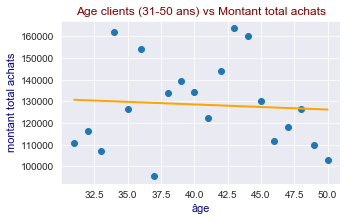

```python
sns.set_style("darkgrid")
plt.figure(figsize=(5,3))
plt.title('Age clients (31-50 ans) vs Montant total achats', fontsize=12, color='maroon')
plt.xlabel('âge', color='darkblue', size=11)
plt.ylabel('montant total achats', color='darkblue', size=11)

# La droite de régression linéaire est du type y = ax + b + epsilon
plt.scatter(x1,y)
# on prend les coef pour const et age pour le calcul du yhat
yhat = x1*-236.8928+1.38e+05
fig = plt.plot(x1,yhat, lw=2, c='orange', label ='regression line')



plt.savefig('img/Q3/2.4.2 age_vs_tot_achats.png', dpi=120, bbox_inches='tight')
plt.show()
plt.close()
```

```python
# coefficient de corrélation de Pearson
ageb = st.pearsonr(ageb["age"],ageb["price"])[0]
round(ageb, 3)
```

```
-0.069
```

##### 4.3 Analyse des plus de 50 ans

```python
# âge c : les plus de 50 ans
agec=table_clean[['age','price']].copy()
# limitation à âge > 50 ans
agec = agec.loc[(agec['age'] > 50),:]
# groupby et sum de 'price'
agec = agec.groupby(['age']).price.sum().reset_index()
agec.describe()
```

|  | age | price |
| --- | --- | --- |
| count | 43.000000 | 43.000000 |
| mean | 72.000000 | 31189.618140 |
| std | 12.556539 | 25170.477866 |
| min | 51.000000 | 1300.030000 |
| 25% | 61.500000 | 9282.210000 |
| 50% | 72.000000 | 24591.770000 |
| 75% | 82.500000 | 50414.690000 |
| max | 93.000000 | 78205.580000 |

```python
# déclaration de la variable dépendante et de la variable indépendante
x1 = agec['age']
y = agec['price']
# régression
x = sm.add_constant(x1)
results = sm.OLS(y,x).fit()
results.summary()
```

OLS Regression Results

| Dep. Variable: | price | R-squared: | 0.881 |
| --- | --- | --- | --- |
| Model: | OLS | Adj. R-squared: | 0.878 |
| Method: | Least Squares | F-statistic: | 304.1 |
| Date: | Tue, 26 Feb 2019 | Prob (F-statistic): | 1.43e-20 |
| Time: | 22:52:11 | Log-Likelihood: | -450.45 |
| No. Observations: | 43 | AIC: | 904.9 |
| Df Residuals: | 41 | BIC: | 908.4 |
| Df Model: | 1 |  |  |
| Covariance Type: | nonrobust |  |  |

|  | coef | std err | t | P>\|t\| | [0.025 | 0.975] |
| --- | --- | --- | --- | --- | --- | --- |
| const | 1.667e+05 | 7884.398 | 21.140 | 0.000 | 1.51e+05 | 1.83e+05 |
| age | -1881.7121 | 107.914 | -17.437 | 0.000 | -2099.650 | -1663.775 |

| Omnibus: | 8.172 | Durbin-Watson: | 1.444 |
| --- | --- | --- | --- |
| Prob(Omnibus): | 0.017 | Jarque-Bera (JB): | 16.080 |
| Skew: | 0.102 | Prob(JB): | 0.000322 |
| Kurtosis: | 5.989 | Cond. No. | 430. |

Warnings:  
[1] Standard Errors assume that the covariance matrix of the errors is correctly specified.

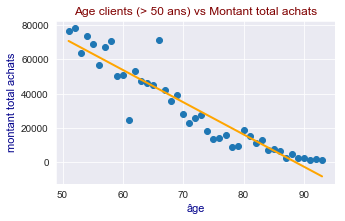

```python
sns.set_style("darkgrid")
plt.figure(figsize=(5,3))
plt.title('Age clients (> 50 ans) vs Montant total achats', fontsize=12, color='maroon')
plt.xlabel('âge', color='darkblue', size=11)
plt.ylabel('montant total achats', color='darkblue', size=11)

# La droite de régression linéaire est du type y = ax + b + epsilon
plt.scatter(x1,y)
# on prend les coef pour const et age pour le calcul du yhat
yhat = x1*-1881.7121+1.667e+05
fig = plt.plot(x1,yhat, lw=2, c='orange', label ='regression line')



plt.savefig('img/Q3/2.4.3 age_vs_tot_achats.png', dpi=120, bbox_inches='tight')
plt.show()
plt.close()
```

```python
# coefficient de corrélation de Pearson
agec = st.pearsonr(agec["age"],agec["price"])[0]
round(agec, 3)
```

```
-0.939
```

**Conclusions**

- Le coéficient de corrélation pour les moins de 30 ans = 0.532
  - la courbe est ascendante, la corrélation moyenne
  - le modèle semble peu solide du fait de la grande dispertion des valeurs
- Le coéficient de corrélation pour les 31 - 50 ans =-0.069
  - pas de corrélation
- Le coéficient de corrélation pour les plus de 50 ans = -0.939
  - la courbe est descendante, la corrélation forte
  - le modèle semble solide du fait de la concentration des valeurs mis à par 2 outliers

## 3. [tdm] Corrélation entre l'âge des clients et le nombre moyen d'achats mensuels

- Nous sommes encore dans un exemple avec deux valeurs quantitatives, mais cette fois-ci entre l'âge et la **fréquence moyenne mensuelle d'achats**
- L'âge entrant en ligne de compte, nous excluerons l'outlier **18 ans**
- Pour ce type de variables nous utilisons le coefficient de corrélation linéaire avec **y =ax + b + epsilon**
- Nous utiliserons une régression linéaire et la méthode OLS (Ordinary Least Square) ou **méthode de moindre carrés**

#### 1. [tdm] Préparation du dataframe

```python
# création du dataframe et compte de id_prod par mois
freq =table_clean[['age','timeline','id_prod']].copy()
# exclusion de l'outlier '18 ans'
freq = freq[(freq['age'] != 18)]
# groupby et sum de 'price'
freq = freq.groupby(['age','timeline']).id_prod.count().reset_index()
freq2 =freq[['age','id_prod']].copy()
freq2 = freq2.groupby(['age']).id_prod.mean().round(2).reset_index()
freq2.describe()
```

|  | age | id_prod |
| --- | --- | --- |
| count | 75.000000 | 75.000000 |
| mean | 56.000000 | 340.336533 |
| std | 21.794495 | 313.011134 |
| min | 19.000000 | 7.000000 |
| 25% | 37.500000 | 93.875000 |
| 50% | 56.000000 | 223.170000 |
| 75% | 74.500000 | 631.000000 |
| max | 93.000000 | 1035.330000 |

#### 2. [tdm] Méthode des moindres carrés (OLS)

```python
# déclaration de la variable dépendante et de la variable indépendante
x1 = freq2['age']
y = freq2['id_prod']
# régression
x = sm.add_constant(x1)
results = sm.OLS(y,x).fit()
results.summary()
```

OLS Regression Results

| Dep. Variable: | id_prod | R-squared: | 0.319 |
| --- | --- | --- | --- |
| Model: | OLS | Adj. R-squared: | 0.309 |
| Method: | Least Squares | F-statistic: | 34.15 |
| Date: | Tue, 26 Feb 2019 | Prob (F-statistic): | 1.33e-07 |
| Time: | 22:52:12 | Log-Likelihood: | -522.50 |
| No. Observations: | 75 | AIC: | 1049. |
| Df Residuals: | 73 | BIC: | 1054. |
| Df Model: | 1 |  |  |
| Covariance Type: | nonrobust |  |  |

|  | coef | std err | t | P>\|t\| | [0.025 | 0.975] |
| --- | --- | --- | --- | --- | --- | --- |
| const | 794.3629 | 83.303 | 9.536 | 0.000 | 628.341 | 960.385 |
| age | -8.1076 | 1.387 | -5.843 | 0.000 | -10.873 | -5.342 |

| Omnibus: | 1.845 | Durbin-Watson: | 0.191 |
| --- | --- | --- | --- |
| Prob(Omnibus): | 0.397 | Jarque-Bera (JB): | 1.800 |
| Skew: | 0.362 | Prob(JB): | 0.407 |
| Kurtosis: | 2.770 | Cond. No. | 167. |

Warnings:  
[1] Standard Errors assume that the covariance matrix of the errors is correctly specified.

#### 3. [tdm] Création du graphique

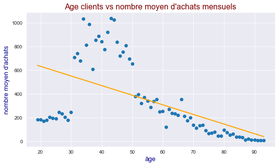

```python
# création du scatterplot Seaborn
sns.set_style("darkgrid")
plt.figure(figsize=(9,5))
plt.title("Age clients vs nombre moyen d'achats mensuels", fontsize=16, color='maroon')

# La droite de régression linéaire est du type y = ax + b
plt.scatter(x1,y)
# on prend les coef pour const et age pour le calcul du yhat
yhat = x1*-8.1076+794.3639
fig = plt.plot(x1,yhat, lw=2, c='orange', label ='regression line')

plt.xlabel('âge', color='darkblue', size=13)
plt.ylabel("nombre moyen d'achats", color='darkblue', size=13)

plt.savefig('img/Q3/3.3 nb_moyen_achat_age.png', dpi=120, bbox_inches='tight')
plt.show()
plt.close()
```

```python
# coefficient de corrélation Pearson
freq2 = st.pearsonr(freq2['age'],freq2['id_prod'])[0]
round(freq2,3)
```

```
-0.565
```

- Nous avons une droite de régression décroissante est assez peu corrélée sauf au-delà de 50 ans
- Nous pouvons découper la courbe en 3 zones : 19-30 ans, 31-50 ans, plus de 50 ans

#### 4. [tdm] Découpage du dataframe en 3 groupes d'âge

- Nous étutions la corrélation pour les 19-30 ans, les 31-50 ans et les 51-93 ans

##### 4.1 Analyse des 19-30 ans

```python
# création du dataframe et compte de id_prod par mois
fra =table_clean[['age','timeline','id_prod']].copy()
# sélection 18 < âge <= 30
fra = fra[(fra['age'] != 18)&(fra['age'] <= 30)]
# groupby et sum de 'price'
fra = fra.groupby(['age','timeline']).id_prod.count().reset_index()
fra2 =fra[['age','id_prod']].copy()
fra2 = fra2.groupby(['age']).id_prod.mean().round(2).reset_index()
fra2.describe()
```

|  | age | id_prod |
| --- | --- | --- |
| count | 12.000000 | 12.000000 |
| mean | 24.500000 | 201.526667 |
| std | 3.605551 | 26.008919 |
| min | 19.000000 | 169.330000 |
| 25% | 21.750000 | 181.685000 |
| 50% | 24.500000 | 194.250000 |
| 75% | 27.250000 | 211.687500 |
| max | 30.000000 | 245.920000 |

```python
# déclaration de la variable dépendante et de la variable indépendante
x1 = fra2['age']
y = fra2['id_prod']
# régression
x = sm.add_constant(x1)
results = sm.OLS(y,x).fit()
results.summary()
```

OLS Regression Results

| Dep. Variable: | id_prod | R-squared: | 0.392 |
| --- | --- | --- | --- |
| Model: | OLS | Adj. R-squared: | 0.331 |
| Method: | Least Squares | F-statistic: | 6.441 |
| Date: | Tue, 26 Feb 2019 | Prob (F-statistic): | 0.0295 |
| Time: | 22:52:12 | Log-Likelihood: | -52.623 |
| No. Observations: | 12 | AIC: | 109.2 |
| Df Residuals: | 10 | BIC: | 110.2 |
| Df Model: | 1 |  |  |
| Covariance Type: | nonrobust |  |  |

|  | coef | std err | t | P>\|t\| | [0.025 | 0.975] |
| --- | --- | --- | --- | --- | --- | --- |
| const | 90.9100 | 44.018 | 2.065 | 0.066 | -7.167 | 188.987 |
| age | 4.5150 | 1.779 | 2.538 | 0.029 | 0.551 | 8.479 |

| Omnibus: | 0.570 | Durbin-Watson: | 2.008 |
| --- | --- | --- | --- |
| Prob(Omnibus): | 0.752 | Jarque-Bera (JB): | 0.032 |
| Skew: | -0.123 | Prob(JB): | 0.984 |
| Kurtosis: | 2.944 | Cond. No. | 178. |

Warnings:  
[1] Standard Errors assume that the covariance matrix of the errors is correctly specified.

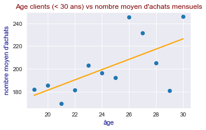

```python
# création du scatterplot Seaborn
sns.set_style("darkgrid")
plt.figure(figsize=(5.,3))
plt.title("Age clients (< 30 ans) vs nombre moyen d'achats mensuels", fontsize=12, color='maroon')

# La droite de régression linéaire est du type y = ax + b
plt.scatter(x1,y)
# on prend les coef pour const et age pour le calcul du yhat
yhat = x1*4.5150 + 90.9100
fig = plt.plot(x1,yhat, lw=2, c='orange', label ='regression line')

plt.xlabel('âge', color='darkblue', size=11)
plt.ylabel("nombre moyen d'achats", color='darkblue', size=11)

plt.savefig('img/Q3/4.1 nb_moyen_achat_age.png', dpi=120, bbox_inches='tight')
plt.show()
plt.close()
```

```python
# calcul de la correlation de Pearson pour les moins de 30 ans
fra2 = st.pearsonr(fra2['age'],fra2['id_prod'])[0]
round(fra2,3)
```

```
0.626
```

##### 4.2 Analyse des 31-50 ans

```python
# création du dataframe et compte de id_prod par mois pour les 31-50 ans
frb =table_clean[['age','timeline','id_prod']].copy()
# groupby et sum de 'price'
frb = frb.groupby(['age','timeline']).id_prod.count().reset_index()
# calcul de la moyenne mensuelle de id_prod
frb1 =frb[['age','id_prod']].copy()
frb1 = frb1.groupby(['age']).id_prod.mean().reset_index()
# limitation à la catégorie 31-50 ans
frb1 = frb1.loc[(frb1['age'] > 30) & (frb1['age'] <= 50),:]
frb1.describe()
```

|  | age | id_prod |
| --- | --- | --- |
| count | 20.00000 | 20.000000 |
| mean | 40.50000 | 818.437500 |
| std | 5.91608 | 129.759130 |
| min | 31.00000 | 607.750000 |
| 25% | 35.75000 | 717.937500 |
| 50% | 40.50000 | 809.583333 |
| 75% | 45.25000 | 894.437500 |
| max | 50.00000 | 1035.333333 |

```python
# déclaration de la variable dépendante et de la variable indépendante
x1 = frb1['age']
y = frb1['id_prod']
# régression
x = sm.add_constant(x1)
results = sm.OLS(y,x).fit()
results.summary()
```

OLS Regression Results

| Dep. Variable: | id_prod | R-squared: | 0.005 |
| --- | --- | --- | --- |
| Model: | OLS | Adj. R-squared: | -0.051 |
| Method: | Least Squares | F-statistic: | 0.08309 |
| Date: | Tue, 26 Feb 2019 | Prob (F-statistic): | 0.776 |
| Time: | 22:52:13 | Log-Likelihood: | -125.13 |
| No. Observations: | 20 | AIC: | 254.3 |
| Df Residuals: | 18 | BIC: | 256.3 |
| Df Model: | 1 |  |  |
| Covariance Type: | nonrobust |  |  |

|  | coef | std err | t | P>\|t\| | [0.025 | 0.975] |
| --- | --- | --- | --- | --- | --- | --- |
| const | 878.6521 | 210.999 | 4.164 | 0.001 | 435.360 | 1321.945 |
| age | -1.4868 | 5.158 | -0.288 | 0.776 | -12.323 | 9.349 |

| Omnibus: | 1.246 | Durbin-Watson: | 1.645 |
| --- | --- | --- | --- |
| Prob(Omnibus): | 0.536 | Jarque-Bera (JB): | 0.993 |
| Skew: | 0.308 | Prob(JB): | 0.609 |
| Kurtosis: | 2.099 | Cond. No. | 290. |

Warnings:  
[1] Standard Errors assume that the covariance matrix of the errors is correctly specified.

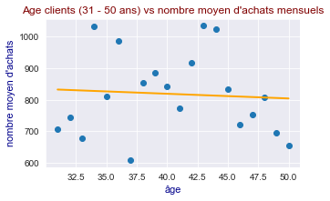

```python
# création du scatterplot Seaborn
sns.set_style("darkgrid")
plt.figure(figsize=(5.,3))
plt.title("Age clients (31 - 50 ans) vs nombre moyen d'achats mensuels", fontsize=12, color='maroon')

# La droite de régression linéaire est du type y = ax + b
plt.scatter(x1,y)
# on prend les coef pour const et age pour le calcul du yhat
yhat = x1*-1.4868 + 878.6521
fig = plt.plot(x1,yhat, lw=2, c='orange', label ='regression line')

plt.xlabel('âge', color='darkblue', size=11)
plt.ylabel("nombre moyen d'achats", color='darkblue', size=11)

plt.savefig('img/Q3/4.2 nb_moyen_achat_age.png', dpi=120, bbox_inches='tight')
plt.show()
plt.close()
```

```python
# calcul de la correlation de Pearson pour les 31-50 ans
frb1 = st.pearsonr(frb1['age'],frb1['id_prod'])[0]
round(frb1,3)
```

```
-0.068
```

##### 4.3 Analyse des plus de 50 ans

```python
# création du dataframe et compte de id_prod par mois pour les 51-93 ans
frc =table_clean[['age','timeline','id_prod']].copy()
# groupby et sum de 'price'
frc = frc.groupby(['age','timeline']).id_prod.count().reset_index()
# calcul de la moyenne mensuelle de id_prod
frc1 = frc[['age','id_prod']].copy()
frc1 = frc1.groupby(['age']).id_prod.mean().reset_index()
# limitation à la catégorie 51-93 ans
frc1 = frc1.loc[(frc1['age'] > 50),:]
frc1.describe()
```

|  | age | id_prod |
| --- | --- | --- |
| count | 43.000000 | 43.000000 |
| mean | 72.000000 | 156.701550 |
| std | 12.556539 | 126.303443 |
| min | 51.000000 | 7.000000 |
| 25% | 61.500000 | 46.791667 |
| 50% | 72.000000 | 122.750000 |
| 75% | 82.500000 | 252.333333 |
| max | 93.000000 | 395.250000 |

```python
# déclaration de la variable dépendante et de la variable indépendante
x1 = frc1['age']
y = frc1['id_prod']
# régression
x = sm.add_constant(x1)
results = sm.OLS(y,x).fit()
results.summary()
```

OLS Regression Results

| Dep. Variable: | id_prod | R-squared: | 0.882 |
| --- | --- | --- | --- |
| Model: | OLS | Adj. R-squared: | 0.879 |
| Method: | Least Squares | F-statistic: | 306.6 |
| Date: | Tue, 26 Feb 2019 | Prob (F-statistic): | 1.23e-20 |
| Time: | 22:52:13 | Log-Likelihood: | -222.62 |
| No. Observations: | 43 | AIC: | 449.2 |
| Df Residuals: | 41 | BIC: | 452.8 |
| Df Model: | 1 |  |  |
| Covariance Type: | nonrobust |  |  |

|  | coef | std err | t | P>\|t\| | [0.025 | 0.975] |
| --- | --- | --- | --- | --- | --- | --- |
| const | 836.8807 | 39.418 | 21.231 | 0.000 | 757.273 | 916.488 |
| age | -9.4469 | 0.540 | -17.510 | 0.000 | -10.537 | -8.357 |

| Omnibus: | 7.924 | Durbin-Watson: | 1.472 |
| --- | --- | --- | --- |
| Prob(Omnibus): | 0.019 | Jarque-Bera (JB): | 15.291 |
| Skew: | 0.048 | Prob(JB): | 0.000478 |
| Kurtosis: | 5.920 | Cond. No. | 430. |

Warnings:  
[1] Standard Errors assume that the covariance matrix of the errors is correctly specified.

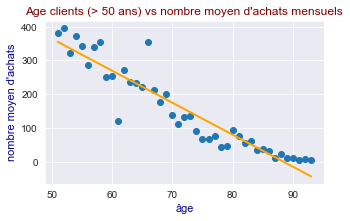

```python
# création du scatterplot Seaborn
sns.set_style("darkgrid")
plt.figure(figsize=(5.,3))
plt.title("Age clients (> 50 ans) vs nombre moyen d'achats mensuels", fontsize=12, color='maroon')

# La droite de régression linéaire est du type y = ax + b
plt.scatter(x1,y)
# on prend les coef pour const et age pour le calcul du yhat
yhat = x1*-9.4469 + 836.8807
fig = plt.plot(x1,yhat, lw=2, c='orange', label ='regression line')

plt.xlabel('âge', color='darkblue', size=11)
plt.ylabel("nombre moyen d'achats", color='darkblue', size=11)

plt.savefig('img/Q3/4.3 nb_moyen_achat_age.png', dpi=120, bbox_inches='tight')
plt.show()
plt.close()
```

```python
# calcul de la correlation de Pearson pour les moins de 30 ans
frc1 = st.pearsonr(frc1['age'],frc1['id_prod'])[0]
round(frc1,3)
```

```
-0.939
```

**Conclusions**

- Le coéficient de corrélation pour les moins de 30 ans = 0.626
  - la courbe est ascendante, la corrélation moyenne
  - le modèle semble peu solide du fait de la grande dispertion des valeurs
- Le coéficient de corrélation pour les 31 - 50 ans =-0.068
  - pas de corrélation
- Le coéficient de corrélation pour les plus de 50 ans = -0.939
  - la courbe est descendante, la corrélation forte
  - le modèle semble solide du fait de la concentration des valeurs mis à par 2 outliers

## 4. [tdm] Corrélation entre l'âge des clients et la taille du panier moyen (nombre d’articles)

#### 1. [tdm] Préparation du dataframe

```python
# création du dataframe et compte de id_prod
pan =table_clean[['session_id','client_id','id_prod','age']].copy()
# compte de 'id_product'
pan = pan.groupby(['session_id','client_id','age']).id_prod.count().reset_index()
# création du dataframe et calcul de la moyenne du nombre de produits achetés par âge
pan2 =pan.copy()
pan2 = pan2.groupby(['age']).id_prod.mean().reset_index()
pan2['id_prod']= round(pan2['id_prod'],2)
pan2.describe()
```

|  | age | id_prod |
| --- | --- | --- |
| count | 76.000000 | 76.000000 |
| mean | 55.500000 | 1.760395 |
| std | 22.083176 | 0.415273 |
| min | 18.000000 | 1.340000 |
| 25% | 36.750000 | 1.437500 |
| 50% | 55.500000 | 1.535000 |
| 75% | 74.250000 | 2.357500 |
| max | 93.000000 | 2.470000 |

#### 2. [tdm] Méthode des moindres carrés (OLS)

```python
# déclaration de la variable dépendante et de la variable indépendante
x1 = pan2['age']
y = pan2['id_prod']
# régression
x = sm.add_constant(x1)
results = sm.OLS(y,x).fit()
results.summary()
```

OLS Regression Results

| Dep. Variable: | id_prod | R-squared: | 0.353 |
| --- | --- | --- | --- |
| Model: | OLS | Adj. R-squared: | 0.345 |
| Method: | Least Squares | F-statistic: | 40.44 |
| Date: | Tue, 26 Feb 2019 | Prob (F-statistic): | 1.50e-08 |
| Time: | 22:52:14 | Log-Likelihood: | -23.978 |
| No. Observations: | 76 | AIC: | 51.96 |
| Df Residuals: | 74 | BIC: | 56.62 |
| Df Model: | 1 |  |  |
| Covariance Type: | nonrobust |  |  |

|  | coef | std err | t | P>\|t\| | [0.025 | 0.975] |
| --- | --- | --- | --- | --- | --- | --- |
| const | 2.3808 | 0.105 | 22.695 | 0.000 | 2.172 | 2.590 |
| age | -0.0112 | 0.002 | -6.359 | 0.000 | -0.015 | -0.008 |

| Omnibus: | 21.990 | Durbin-Watson: | 0.222 |
| --- | --- | --- | --- |
| Prob(Omnibus): | 0.000 | Jarque-Bera (JB): | 7.946 |
| Skew: | 0.544 | Prob(JB): | 0.0188 |
| Kurtosis: | 1.849 | Cond. No. | 162. |

Warnings:  
[1] Standard Errors assume that the covariance matrix of the errors is correctly specified.

#### 3. [tdm] Création du graphique

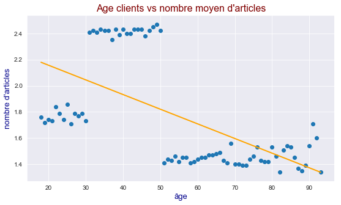

```python
# création du scatterplot Seaborn
sns.set_style("darkgrid")
plt.figure(figsize=(9,5))


# La droite de régression linéaire est du type y = ax + b
plt.scatter(x1,y)
# on prend les coef pour const et age pour le calcul du yhat
yhat = x1*-0.0112+2.3808
fig = plt.plot(x1,yhat, lw=2, c='orange', label ='regression line')

plt.title("Age clients vs nombre moyen d'articles", fontsize=16, color='maroon')
plt.xlabel('âge', color='darkblue', size=13)
plt.ylabel("nombre d'articles", color='darkblue', size=13)

plt.savefig('img/Q3/3.3 nb_moyen_articles_age.png', dpi=120, bbox_inches='tight')
plt.show()
plt.close()
```

```python
pear = st.pearsonr(pan2['age'],pan2['id_prod'])[0]
round(pear, 3)
```

```
-0.594
```

- Les données sont assez peu corrélées, ce qui est confirmé par le graphique
- On distingue clairement 3 zones qui que l'on pourrait calculer individuellement
  - les 18-30 ans
  - les 31 à 50 ans
  - les 51 à 93 ans
  - Au delà, il y a peu de clients et ce sont des outliers

#### 4. [tdm] Découpage du dataframe en 3 groupes d'âge

- Nous calculons la corrélation de Pearson pour les 18-30 ans, les 31-50 ans et les 51-90 ans

```python
# création du dataframe et compte de id_prod pour les moins de 30 ans
pana =table_clean[['session_id','client_id','id_prod','age']].copy()
# compte de 'id_product'
pana = pana.groupby(['session_id','client_id','age']).id_prod.count().reset_index()
# création du dataframe et calcul de la moyenne du nombre de produits achetés par âge
pana1 =pana.copy()
pana1 = pana1.groupby(['age']).id_prod.mean().reset_index()
pana1['id_prod']= round(pana1['id_prod'],2)
# limitation à 30 ans inclus
pana1 = pana1.loc[(pana1['age'] <= 30),:]
pana1.describe()
```

|  | age | id_prod |
| --- | --- | --- |
| count | 13.00000 | 13.000000 |
| mean | 24.00000 | 1.766923 |
| std | 3.89444 | 0.045896 |
| min | 18.00000 | 1.710000 |
| 25% | 21.00000 | 1.730000 |
| 50% | 24.00000 | 1.760000 |
| 75% | 27.00000 | 1.790000 |
| max | 30.00000 | 1.860000 |

```python
# déclaration de la variable dépendante et de la variable indépendante
x1 = pana1['age']
y = pana1['id_prod']
# régression
x = sm.add_constant(x1)
results = sm.OLS(y,x).fit()
results.summary()
```

OLS Regression Results

| Dep. Variable: | id_prod | R-squared: | 0.017 |
| --- | --- | --- | --- |
| Model: | OLS | Adj. R-squared: | -0.072 |
| Method: | Least Squares | F-statistic: | 0.1907 |
| Date: | Tue, 26 Feb 2019 | Prob (F-statistic): | 0.671 |
| Time: | 22:52:15 | Log-Likelihood: | 22.244 |
| No. Observations: | 13 | AIC: | -40.49 |
| Df Residuals: | 11 | BIC: | -39.36 |
| Df Model: | 1 |  |  |
| Covariance Type: | nonrobust |  |  |

|  | coef | std err | t | P>\|t\| | [0.025 | 0.975] |
| --- | --- | --- | --- | --- | --- | --- |
| const | 1.7300 | 0.086 | 20.217 | 0.000 | 1.542 | 1.918 |
| age | 0.0015 | 0.004 | 0.437 | 0.671 | -0.006 | 0.009 |

| Omnibus: | 2.008 | Durbin-Watson: | 2.697 |
| --- | --- | --- | --- |
| Prob(Omnibus): | 0.366 | Jarque-Bera (JB): | 1.230 |
| Skew: | 0.733 | Prob(JB): | 0.541 |
| Kurtosis: | 2.654 | Cond. No. | 158. |

Warnings:  
[1] Standard Errors assume that the covariance matrix of the errors is correctly specified.

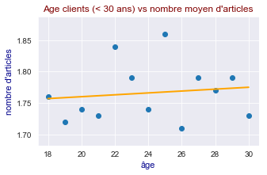

```python
# création du scatterplot Seaborn
sns.set_style("darkgrid")
plt.figure(figsize=(5,3))


# La droite de régression linéaire est du type y = ax + b
plt.scatter(x1,y)
# on prend les coef pour const et age pour le calcul du yhat
yhat = x1*0.0015 + 1.7300
fig = plt.plot(x1,yhat, lw=2, c='orange', label ='regression line')

plt.title("Age clients (< 30 ans) vs nombre moyen d'articles", fontsize=12, color='maroon')
plt.xlabel('âge', color='darkblue', size=11)
plt.ylabel("nombre d'articles", color='darkblue', size=11)

plt.savefig('img/Q3/4.1 nb_moyen_articles_age.png', dpi=120, bbox_inches='tight')
plt.show()
plt.close()
```

```python
# calcul de la correlation de Pearson pour les moins de 30 ans
pana1 = st.pearsonr(pana1['age'],pana1['id_prod'])[0]
round(pana1,3)
```

```
0.131
```

##### 4.2 Analyse des 31-50 ans

```python
# création du dataframe et compte de id_prod pour les 31 à 50 ans
panb =table_clean[['session_id','client_id','id_prod','age']].copy()
# compte de 'id_product'
panb = panb.groupby(['session_id','client_id','age']).id_prod.count().reset_index()
# création du dataframe et calcul de la moyenne du nombre de produits achetés par âge
panb1 =panb.copy()
panb1 = panb1.groupby(['age']).id_prod.mean().reset_index()
panb1['id_prod']= round(panb1['id_prod'],2)
# limitation de 31 à 50 ans
panb1 = panb1.loc[(panb1['age'] > 30) & (panb1['age'] <= 50),:]
panb1.describe()
```

|  | age | id_prod |
| --- | --- | --- |
| count | 20.00000 | 20.000000 |
| mean | 40.50000 | 2.417000 |
| std | 5.91608 | 0.025361 |
| min | 31.00000 | 2.350000 |
| 25% | 35.75000 | 2.407500 |
| 50% | 40.50000 | 2.420000 |
| 75% | 45.25000 | 2.430000 |
| max | 50.00000 | 2.470000 |

```python
# déclaration de la variable dépendante et de la variable indépendante
x1 = panb1['age']
y = panb1['id_prod']
# régression
x = sm.add_constant(x1)
results = sm.OLS(y,x).fit()
results.summary()
```

OLS Regression Results

| Dep. Variable: | id_prod | R-squared: | 0.091 |
| --- | --- | --- | --- |
| Model: | OLS | Adj. R-squared: | 0.041 |
| Method: | Least Squares | F-statistic: | 1.802 |
| Date: | Tue, 26 Feb 2019 | Prob (F-statistic): | 0.196 |
| Time: | 22:52:16 | Log-Likelihood: | 46.580 |
| No. Observations: | 20 | AIC: | -89.16 |
| Df Residuals: | 18 | BIC: | -87.17 |
| Df Model: | 1 |  |  |
| Covariance Type: | nonrobust |  |  |

|  | coef | std err | t | P>\|t\| | [0.025 | 0.975] |
| --- | --- | --- | --- | --- | --- | --- |
| const | 2.3646 | 0.039 | 60.004 | 0.000 | 2.282 | 2.447 |
| age | 0.0013 | 0.001 | 1.342 | 0.196 | -0.001 | 0.003 |

| Omnibus: | 5.852 | Durbin-Watson: | 2.242 |
| --- | --- | --- | --- |
| Prob(Omnibus): | 0.054 | Jarque-Bera (JB): | 3.543 |
| Skew: | -0.950 | Prob(JB): | 0.170 |
| Kurtosis: | 3.800 | Cond. No. | 290. |

Warnings:  
[1] Standard Errors assume that the covariance matrix of the errors is correctly specified.

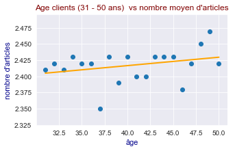

```python
# création du scatterplot Seaborn
sns.set_style("darkgrid")
plt.figure(figsize=(5,3))


# La droite de régression linéaire est du type y = ax + b
plt.scatter(x1,y)
# on prend les coef pour const et age pour le calcul du yhat
yhat = x1*0.0013 + 2.3646
fig = plt.plot(x1,yhat, lw=2, c='orange', label ='regression line')

plt.title("Age clients (31 - 50 ans)  vs nombre moyen d'articles", fontsize=12, color='maroon')
plt.xlabel('âge', color='darkblue', size=11)
plt.ylabel("nombre d'articles", color='darkblue', size=11)

plt.savefig('img/Q3/4.2 nb_moyen_articles_age.png', dpi=120, bbox_inches='tight')
plt.show()
plt.close()
```

```python
# calcul de la correlation de Pearson pour les 31 à 50 ans
panb1 = st.pearsonr(panb1['age'],panb1['id_prod'])[0]
round(panb1,3)
```

```
0.302
```

##### 4.3 Analyse des 51-90 ans

```python
# création du dataframe et compte de id_prod pour les 51 à 90 ans
panc =table_clean[['session_id','client_id','id_prod','age']].copy()
# compte de 'id_product'
panc = panc.groupby(['session_id','client_id','age']).id_prod.count().reset_index()
# création du dataframe et calcul de la moyenne du nombre de produits achetés par âge
panc1 =panc.copy()
panc1 = panc1.groupby(['age']).id_prod.mean().reset_index()
panc1['id_prod']= round(panc1['id_prod'],2)
# limitation de 51 à 90 ans
panc1 = panc1.loc[(panc1['age'] > 50) & (panc1['age'] <= 90),:]
panc1.describe()
```

|  | age | id_prod |
| --- | --- | --- |
| count | 40.000000 | 40.000000 |
| mean | 70.500000 | 1.445750 |
| std | 11.690452 | 0.052667 |
| min | 51.000000 | 1.340000 |
| 25% | 60.750000 | 1.410000 |
| 50% | 70.500000 | 1.440000 |
| 75% | 80.250000 | 1.470000 |
| max | 90.000000 | 1.560000 |

```python
# déclaration de la variable dépendante et de la variable indépendante
x1 = panc1['age']
y = panc1['id_prod']
# régression
x = sm.add_constant(x1)
results = sm.OLS(y,x).fit()
results.summary()
```

OLS Regression Results

| Dep. Variable: | id_prod | R-squared: | 0.006 |
| --- | --- | --- | --- |
| Model: | OLS | Adj. R-squared: | -0.020 |
| Method: | Least Squares | F-statistic: | 0.2257 |
| Date: | Tue, 26 Feb 2019 | Prob (F-statistic): | 0.637 |
| Time: | 22:52:17 | Log-Likelihood: | 61.618 |
| No. Observations: | 40 | AIC: | -119.2 |
| Df Residuals: | 38 | BIC: | -115.9 |
| Df Model: | 1 |  |  |
| Covariance Type: | nonrobust |  |  |

|  | coef | std err | t | P>\|t\| | [0.025 | 0.975] |
| --- | --- | --- | --- | --- | --- | --- |
| const | 1.4213 | 0.052 | 27.305 | 0.000 | 1.316 | 1.527 |
| age | 0.0003 | 0.001 | 0.475 | 0.637 | -0.001 | 0.002 |

| Omnibus: | 0.283 | Durbin-Watson: | 1.635 |
| --- | --- | --- | --- |
| Prob(Omnibus): | 0.868 | Jarque-Bera (JB): | 0.339 |
| Skew: | 0.182 | Prob(JB): | 0.844 |
| Kurtosis: | 2.734 | Cond. No. | 442. |

Warnings:  
[1] Standard Errors assume that the covariance matrix of the errors is correctly specified.

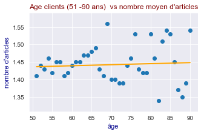

```python
# création du scatterplot Seaborn
sns.set_style("darkgrid")
plt.figure(figsize=(5,3))


# La droite de régression linéaire est du type y = ax + b
plt.scatter(x1,y)
# on prend les coef pour const et age pour le calcul du yhat
yhat = x1*0.0003 + 1.4213
fig = plt.plot(x1,yhat, lw=2, c='orange', label ='regression line')

plt.title("Age clients (51 -90 ans)  vs nombre moyen d'articles", fontsize=12, color='maroon')
plt.xlabel('âge', color='darkblue', size=11)
plt.ylabel("nombre d'articles", color='darkblue', size=11)

plt.savefig('img/Q3/4.3 nb_moyen_articles_age.png', dpi=120, bbox_inches='tight')
plt.show()
plt.close()
```

```python
# calcul de la correlation de Pearson pour les moins de 30 ans
panc1 = st.pearsonr(panc1['age'],panc1['id_prod'])[0]
round(panc1,3)
```

```
0.077
```

**Conclusion**

- Avec 0.131, 0.302 et 0.077 aucune des trois zones n'est corrélée

## 5. [tdm] Corrélation entre l'âge des clients et les catégories de produits achetés

- Nous avons une variable quantitative discrète (l'âge) et une qualitative nominale (la catégorie)
- Nous utiliserons la méthode **ANOVA**. Nous allons déterminer la somme des carrés intra-classes et inter-classes
- Il faudra utiliser le test de [Fisher](https://www.youtube.com/watch?v=y8nRhsixBPs) pour la vérification des hypothèses

#### 1. [tdm] Préparation du dataframe et affichage du boxplot

```python
age=table_clean[['categ','age']].copy()
# transformation de Float dans 'categ' en object
age['categ'] = age['categ'].astype('object', copy=False)
age.head(1)
```

|  | categ | age |
| --- | --- | --- |
| 0 | 1 | 69.0 |

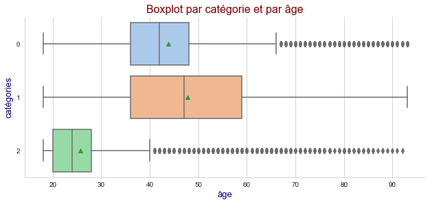

```python
# création du boxplot par catégories et par âge
sns.set_style("whitegrid")
sns.catplot(x='age', y='categ', data=age, orient="h", palette="pastel", height=4, aspect=2.2, showmeans =True, kind="box")

# titre et labels
plt.title("Boxplot par catégorie et par âge", fontsize=16, color = 'maroon')
plt.xlabel('âge', color='darkblue', size=13)
plt.ylabel("catégories", color='darkblue', size=13)

plt.savefig('img/Q3/5.1 boxplot_cat_age.png', dpi=120, bbox_inches='tight')
plt.show()
plt.close()
```

**Conclusions**

#### 2. [tdm] Calculs préparatoires

```python
# Count et Mean de 'age' total
c = age['age'].count()
m = age['age'].mean()
print('age count:',c,'|','age mean:',round(m,3))
```

```
age count: 313651 | age mean: 44.207
```

```python
# Count et Mean de âge catégorie 0
a0 = age[age['categ']==0].copy()

c0 = a0['age'].count()
m0 = a0['age'].mean()
print('a0 count:',c0,'|','a0 mean',round(m0,3))
```

```
a0 count: 195270 | a0 mean 43.8
```

```python
# Count et Mean de âge catégorie 1
a1 = age[age['categ']==1].copy()

c1 = a1['age'].count()
m1 = a1['age'].mean()
print('a1 count:',c1,'|','a1 mean',round(m1,3))
```

```
a1 count: 102625 | a1 mean 47.814
```

```python
# Count et Mean de âge catégorie 2
a2 = age[age['categ']==2].copy()

c2 = a2['age'].count()
m2 = a2['age'].mean()
print('a2 count:',c2,'|','a2 mean',round(m2,3))
```

```
a2 count: 15756 | a2 mean 25.751
```

**Récapitulatif**

- Le facteur 'catégories' comporte **k = 3** modalités
- Le nombre total de données de 'age' est de **N = 313651**
- Nombre de données de 'age' par catégorie
  - **n0** = 195270
  - **n1** = 102625
  - **n2** = 15756
- **N = n0 +n1 +n2**
- Degrés de liberté
  - Degrés de liberté de catégories DDL **k-1 = 2**
  - Degrés de liberté de âge DDL **N-k = 313648**
- Moyenne
  - La moyenne d'âge globale (Grand Mean) est de **44.207 ans**
  - La moyenne d'âge de la catégorie 0 est de **43.800 ans**
  - La moyenne d'âge de la catégorie 1 est de **47.814 ans**
  - La moyenne d'âge de la catégorie 2 est de **25.751 ans**

#### 3. [tdm] ANOVA

- La somme des carrés totaux (SCT) est la somme des distances au carré entre chaque valeur observée et la moyenne globale (Grand Mean).
- Elle peut être décomposée en deux éléments :
  - La somme des Carrés Factoriels (SCF) imputable aux modalités de la variable étudiée (les catégories)
  - La Somme des Carrés Résiduels (SCR) est la somme des distances au carré entre chaque valeur observée et la moyenne de chaque catégorie  
    **SCT = SCF + SCR**  
    variation totale = variation interclasse + variation intraclasse

##### 3.1 Calcul de la dispersion totale des données

```python
# Somme des carrés totaux
SCT = sum((age['age']-age['age'].mean())**2)
round(SCT,2)
```

```
59705564.51
```

##### 3.2 Calcul de la Somme des Carrés Factoriels

```python
# SCF de cat0
SCF0 = a0.count()*(a0['age'].mean()-age['age'].mean())**2
round(SCF0['age'],2)
```

```
32297.85
```

```python
# SCF de cat1
SCF1 = a1.count()*(a1['age'].mean()-age['age'].mean())**2
round(SCF1['age'],2)
```

```
1335411.37
```

```python
# SCF de cat2
SCF2 = a2.count()*(a2['age'].mean()-age['age'].mean())**2
round(SCF2['age'],2)
```

```
5366499.27
```

```python
# SCF totale
SCF = SCF0 + SCF1 + SCF2
round(SCF['age'],2)
```

```
6734208.49
```

##### 3.3 Calcul de la Somme des Carrés Résiduels

```python
# SCR de cat0
SCR0 = sum((a0['age']-a0['age'].mean())**2)
round(SCR0,2)
```

```
25881944.2
```

```python
# SCR de cat1
SCR1 = sum((a1['age']-a1['age'].mean())**2)
round(SCR1,2)
```

```
25627629.1
```

```python
# SCR de cat2
SCR2 = sum((a2['age']-a2['age'].mean())**2)
round(SCR2,2)
```

```
1461782.73
```

```python
# SCR totale
SCR = SCR0 + SCR1 + SCR2
round(SCR,2)
```

```
52971356.02
```

#### 4. [tdm] F distribution (Fisher-Snedecor)

##### 4.1 Calcul des variances factorielle et résiduelle

```python
# Variance factorielle
CMF = SCF/(3-1)
round(CMF['age'],2)
```

```
3367104.25
```

```python
# Variance résiduelle
CMR = SCR/(age['age'].count() - 3)
round(CMR,2)
```

```
168.89
```

##### 4.2 Test statistique de Fisher (F-test)

```python
# F-test
F = CMF/CMR
round(F['age'],2)
```

```
19936.92
```

```python
# p_value
F, df1, df2 = 19936.916703633964, 2, 313648

pVal = 1-st.f.sf(F, df1, df2)
pVal
```

```
1.0
```

#### 5. [tdm] Vérification des hypothèses

**Seuil de tolérance α** : 0.05 (5%) pour l'hypothèse nulle

**Test d'hypothèse**

- **H0** = Les catégories nont pas d'impact (les moyennes de différentes catégories sont égales)
- **H1** = Les catégories ont un impact (aux moins 2 moyennes sont différentes)

[**Calcul de la valeur F critique**](http://www.statdistributions.com/f/) pour **α** = 0.05

[figure not shown]

**Conclusions**

- Notre valeur de F calculée (19936.92) est très largement supérieure à la valeur F critique (3.041)
- L'hypothèse H0 est à rejeter
- Au moins deux catégories ont un impact très sigificatif